# Visualisation_project

Siva Manoj

2022-11-01

### Abstract

The project’s primary goal is to determine the impact of various factors on in-hospital mortality rate.

### Introduction

The state of being mortal is referred to as mortality. In the medical field, mortality is also known as the death rate. In this data set, in-hospital mortality is the death rate among heart failure patients admitted to the ICU. The data was compiled from hospitals where heart failure patients were admitted to the intensive care unit for treatment. Patients with a diagnosis of Heart Failure, identified by manual review of ICD-9 codes, and whose age is more than 15 years at the time of ICU admission were included in the study.

### Dataset Description

The dataset includes 51 characteristics from 1177 heart failure patients. There are 39 numerical variables and 12 categorical variables in the dataset. In the outcome variable, 0 means patient is alive and 1 means patient died, in the gender variable, 1 means female and 2 means male, and in all other categorical variables, 0 means Yes and 1 means No.

The following variables are considered in this component:

##### Numerical variables

- Age
- Heart Rate
- BMI
- Systolic Blood Pressure
- Diastolic Blood Pressure
- Respiratory Rate
- SP O2
- Glucose

##### Categorical variables

- Gender
- Hypertensive
- Diabetes
- atrial fibrillation
- CHD with no MI
- anaemia deficiency
- Depression
- Hyperlipemia
- Renal Failure
- COPD

### Graphical Presentation of Variables

##### Stacked Graph

The following stacked graphs show the effect of categorical variables on the in-hospital mortality rate.

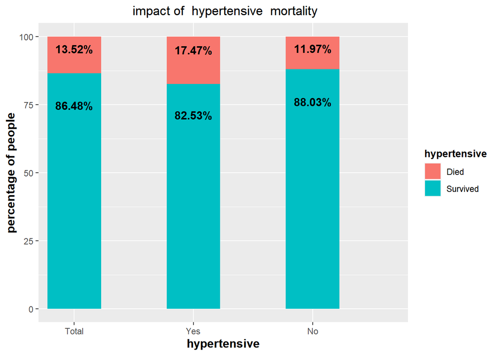

The in-hospital mortality rate is 13.52% for the total sample. However, in hypertensive patients, the rate rises to 17.47%. The rate in patients who do not have hypertension is 11.97%.

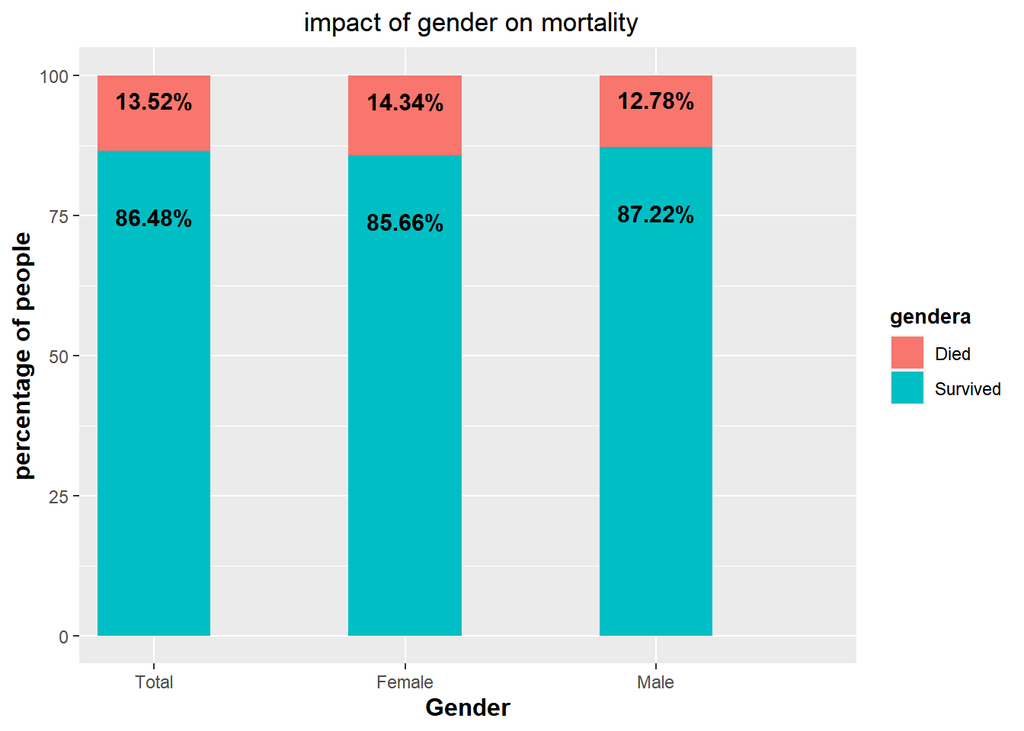

Females have a higher mortality rate than males for heart failure patients.

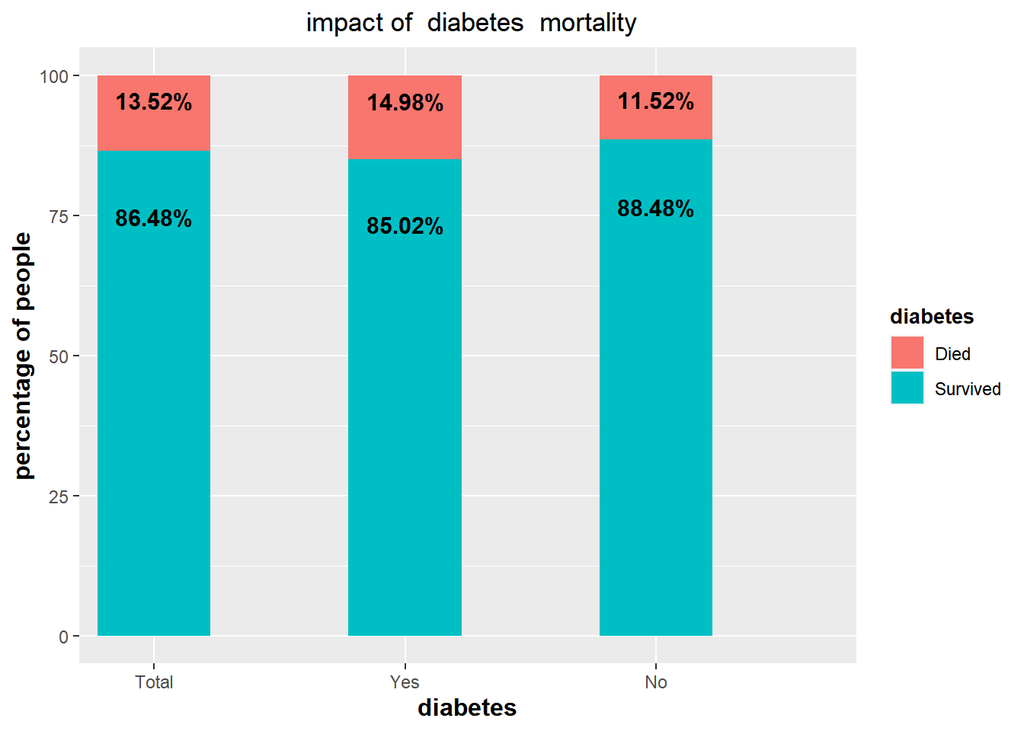

In diabetes patients, the mortality rate rises to 14.98%. In patients who do not have diabetes, the rate is 11.52%.

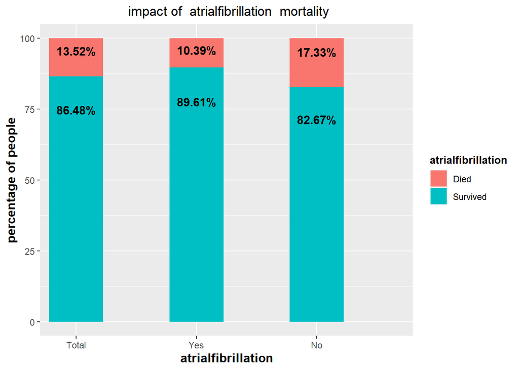

In atrial fibrillation patients, the mortality rate reduces to 10.39%. In patients who do not have atrial fibrillation, the rate is 17.33%.

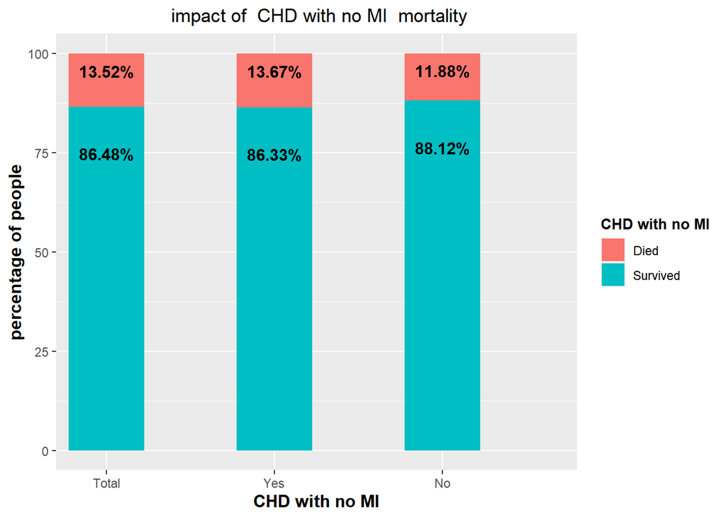

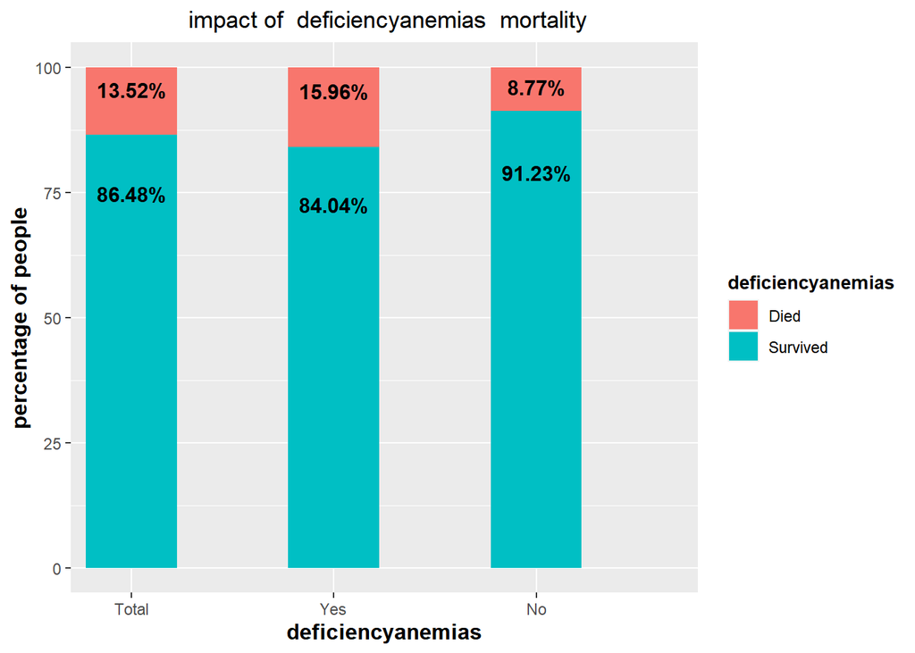

The anaemia deficiency factor has increased in-hospital mortality.

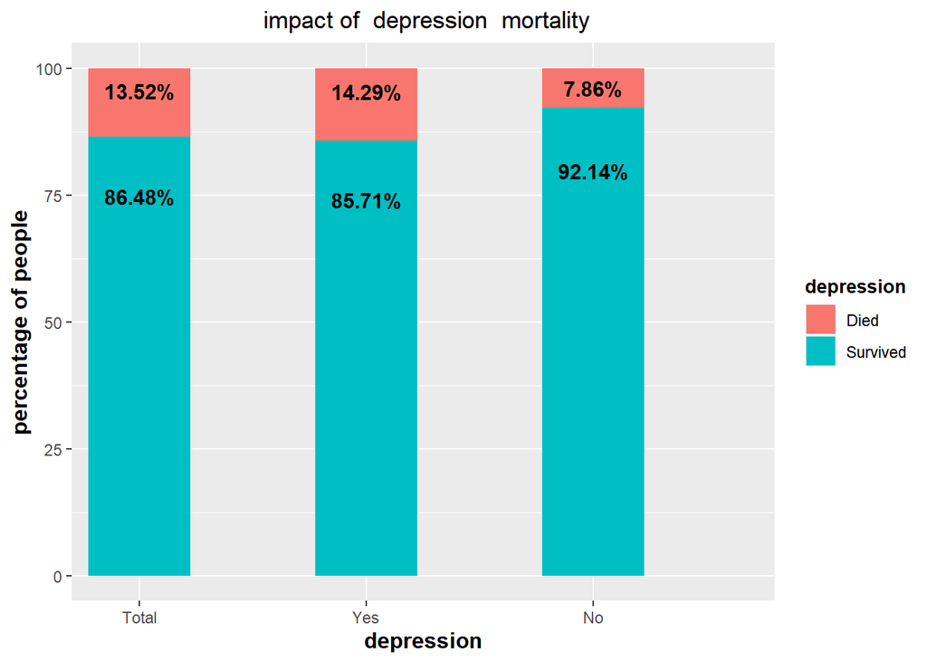

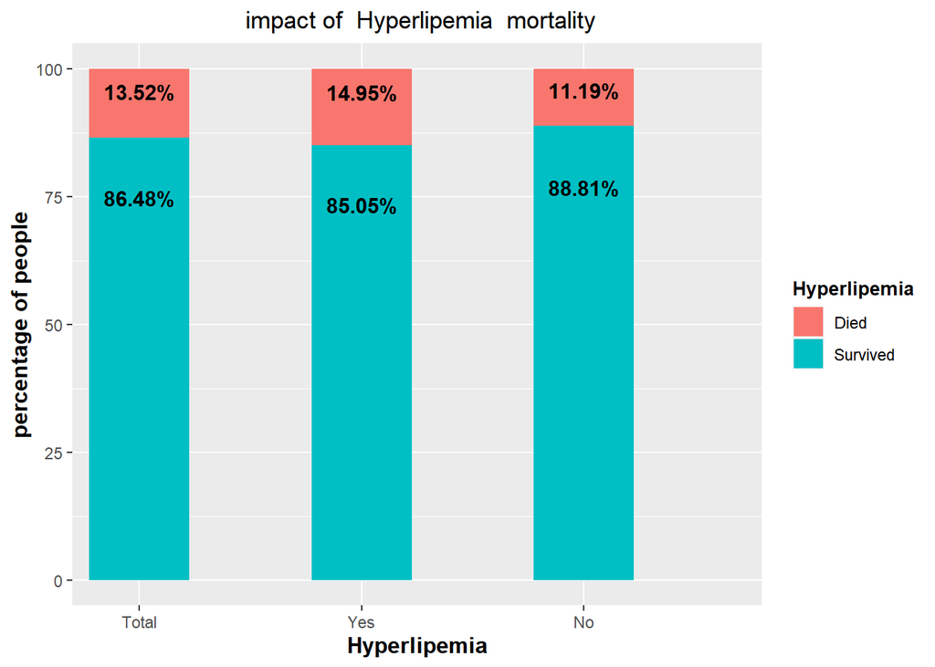

The Hyperlipemia factor has increased the in-hospital mortality rate.

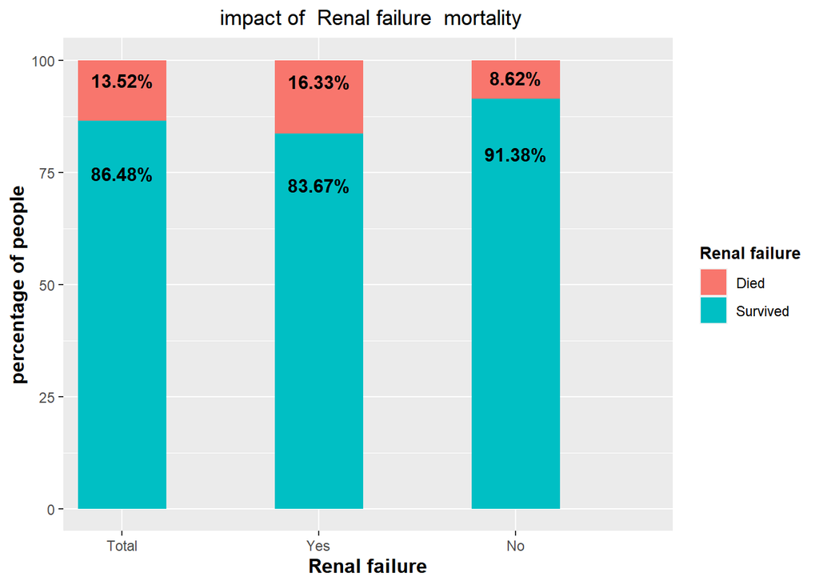

Renal failure increased the rate of in-hospital mortality.

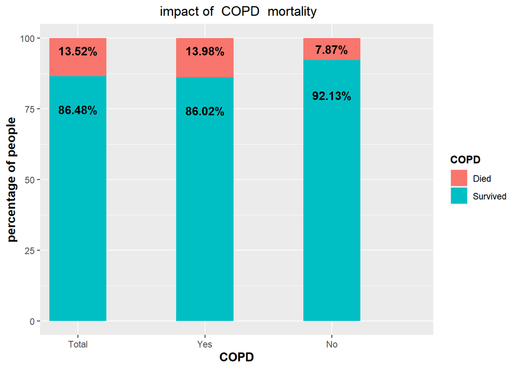

##### Histograms

The histograms below show the proportion of deceased patients in relation to the continuous variables Age, BMI, Heart Rate, Systolic Blood Pressure, Diastolic Blood Pressure, and Respiratory Rate.

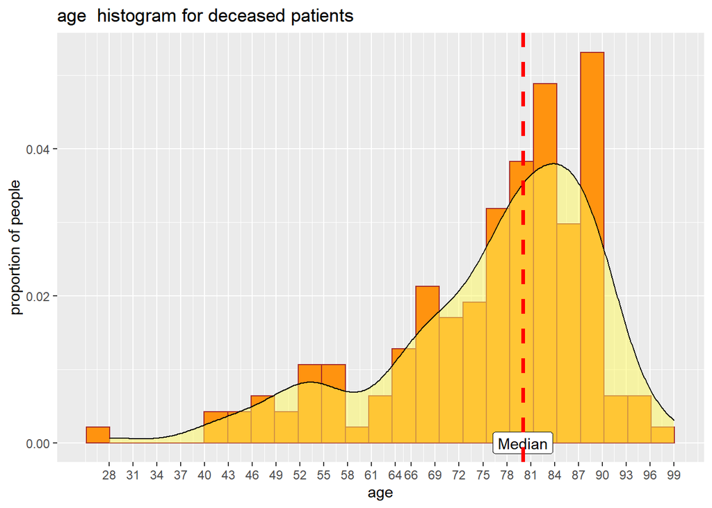

The histogram is drawn for the age of deceased persons in this dataset, and from it we can conclude that In-hospital mortality is almost zero in the age group of less than 40 years, low from 40 to 65 years, and very high from 65 to 90 years.

The median age for deceased persons is 80.

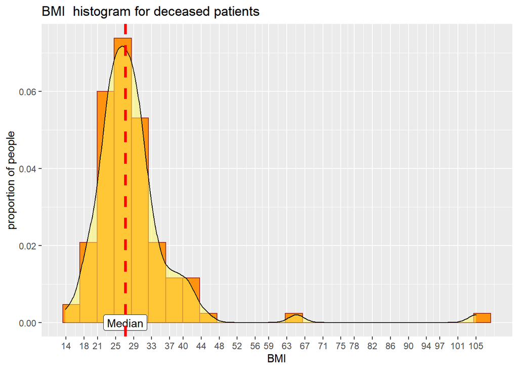

The histogram for the BMI of deceased persons in this dataset is drawn, and we can conclude from it that in-hospital mortality is low between BMI 14 and 21, and very high between BMI 21 and 33.

The median BMI for deceased persons is 28.

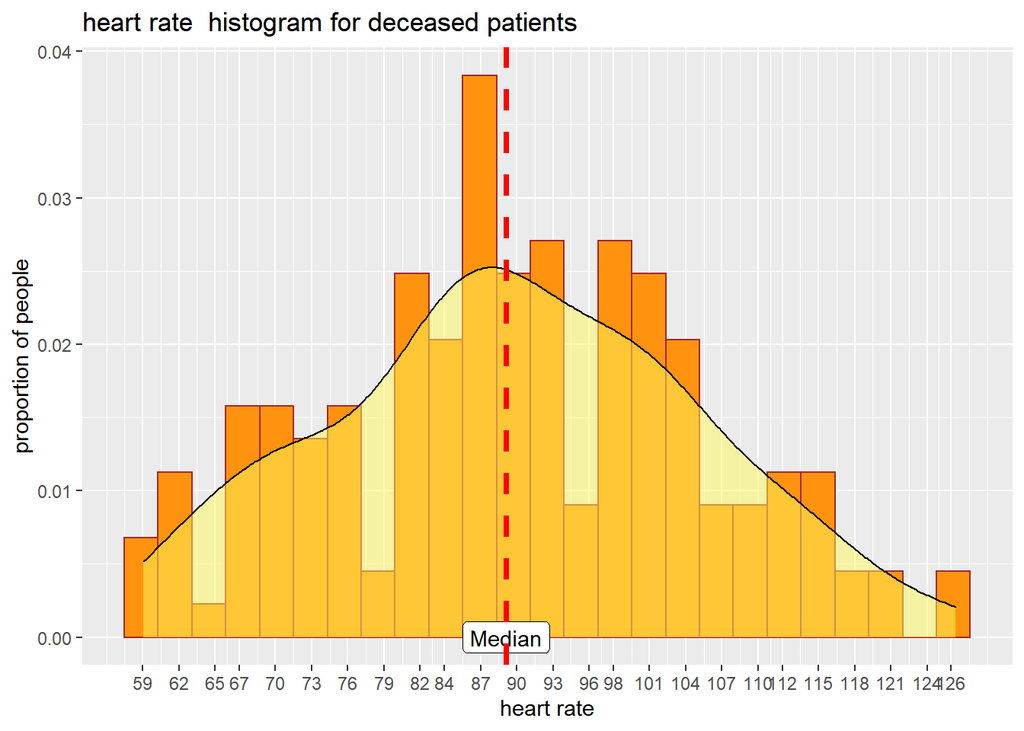

We can conclude from the histogram for the Heart Rate of deceased people in this dataset that in-hospital mortality is low between Heart Rates 59 and 79 compared to Heart Rates 79 and 104.

The median heart rate for deceased persons is 89.

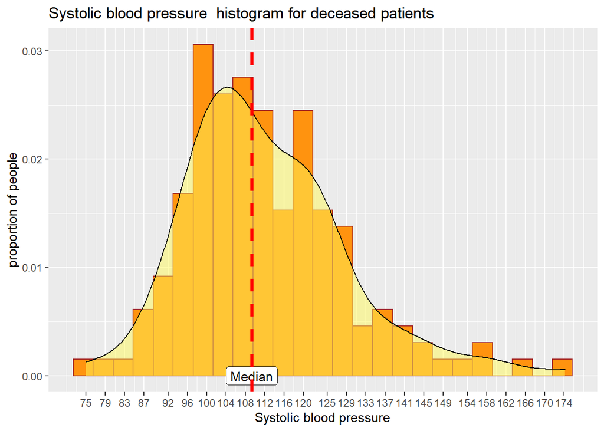

We can conclude from the histogram for the Systolic Blood Pressure of deceased people in this dataset that in-hospital mortality is low between Systolic Blood Pressure 75 to 95 and above 133, and very high between Systolic Blood Pressure 95 to 125.

The median Systolic Blood Pressure for deceased persons is 109.

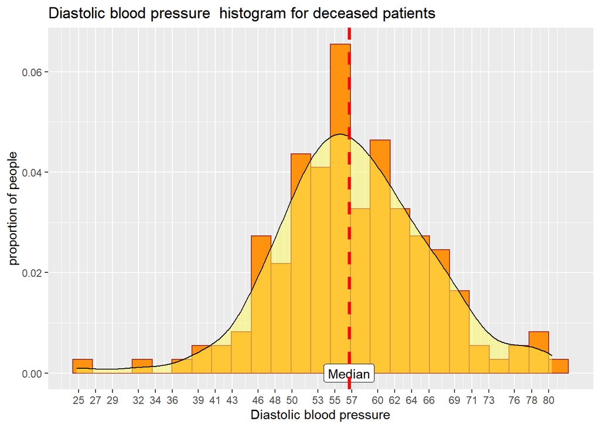

Based on the histogram for the Diastolic Blood Pressure of deceased people in this dataset, we can conclude that in-hospital mortality is low between Diastolic Blood Pressure 25 to 45 and 66 to 80, but very high between Diastolic Blood Pressure 48 to 66.

The median Daistolic Blood Pressure for deceased persons is 57.

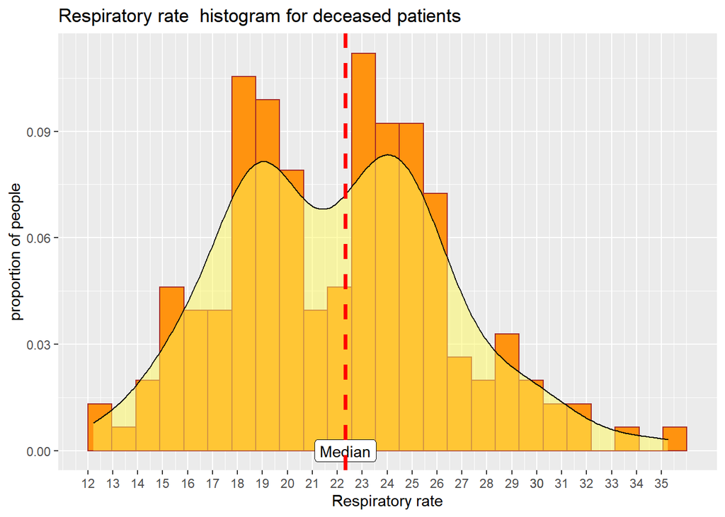

Based on the histogram for the Respiratory Rate of deceased people in this dataset, we can conclude that in-hospital mortality is high between 18 to 21 and 23 to 25.5 the median Respiratory for deceased persons is 22.2.

##### BMI classification

BMI is calculated by dividing a person’s weight in kilogrammes by their height in metres squared.

BMI can be classified as 4 categories. if BMI < 18.5 it comes under the category of Under weight if BMI is 18.5 to 25 it comes under Normal weight if BMI is 25 to 30 it comes under Over weight if BMI is over 30 it comes under Obese

##### Box plot

The box plot illustrates the distribution of continuous variables for each category of BMI of deceased patients.

The box in the Box Plot extends from the lower quartile to the upper quartile. the black line represents the median of the distribution.

- The median of a data set divides the data into two equal portions.
- The lower quartile is the point where 25% of the data points are below it.
- The upper quartile is the age where 75% of the data points are below it.
- The difference between the upper quartile and the lower quartile is called the inter-quartile range.
- A data point needs to fall more than 1.5 times the Interquartile range below the lower quartile to be considered a low outlier.
- A data point needs to fall more than 1.5 times the Interquartile range above the upper quartile to be considered a high outlier.

Outliers are shown as black points and mean is represented as white square point.

The box plot is drawn for continuous variable categorised by BMI classification

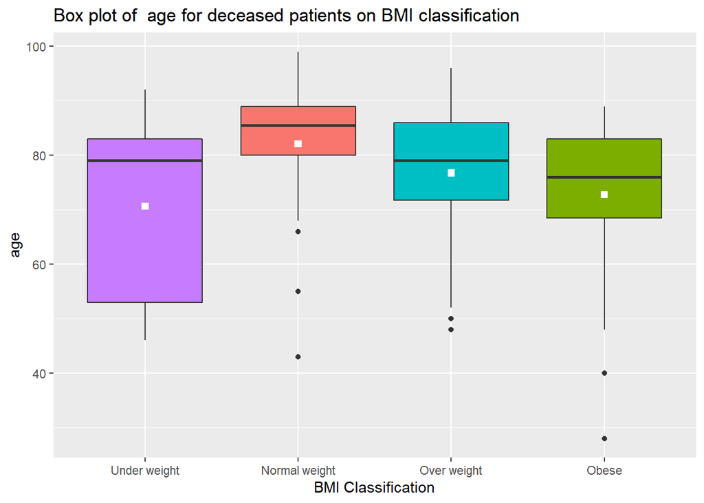

the lower quartile is very small in Under wight category compared to remaining categories. In the Underweight category, 25% of deceased patients are under the age of 52. It is 80 for patients of normal weight.

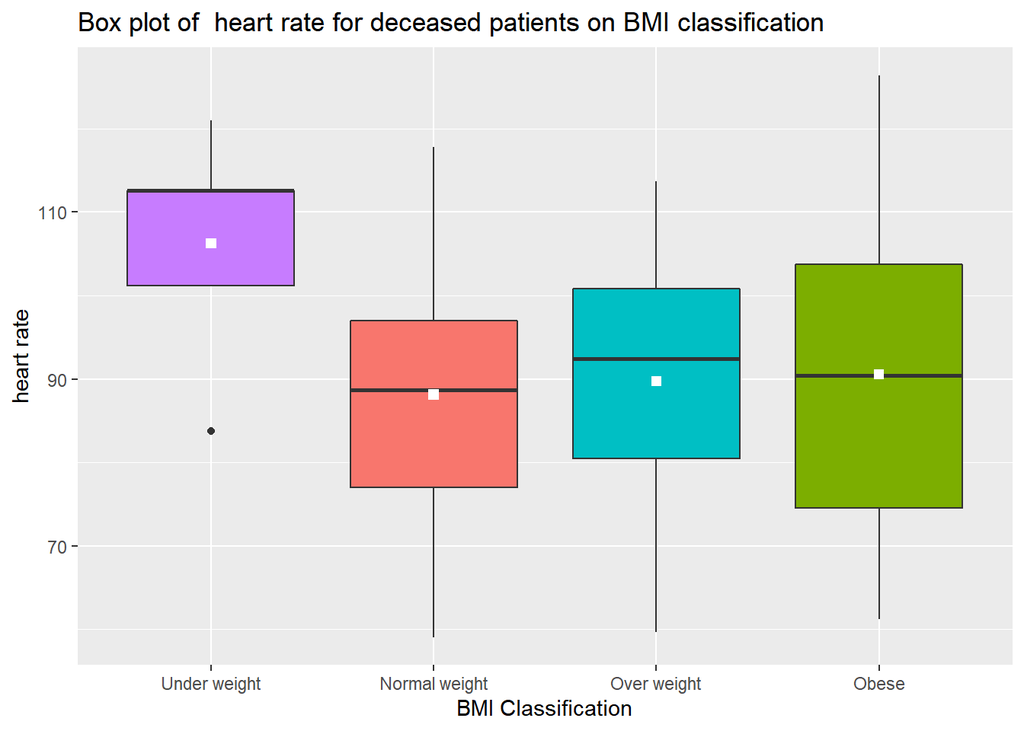

the range of heart rate for deceased patients under obese category is high compared to remaining categories

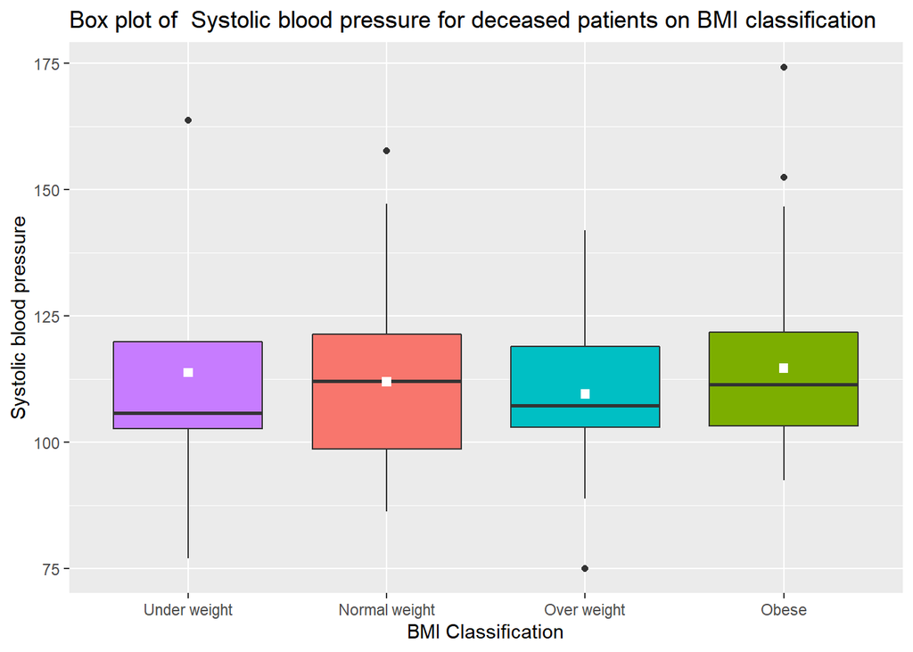

The median of Systolic Blood Pressure for deceased patients under normal weight category is high.

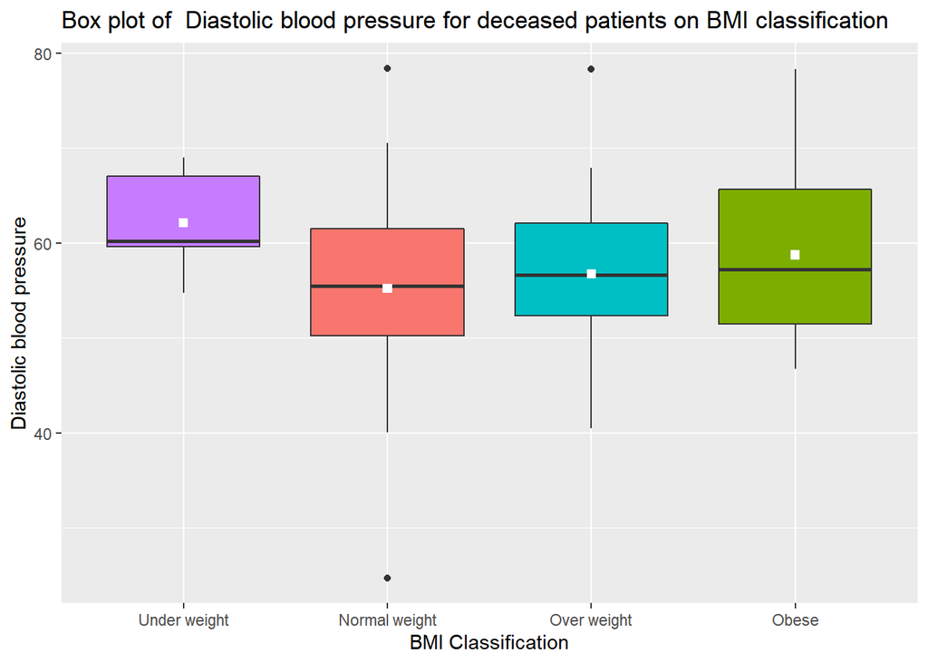

The median of Diastolic Blood Pressure for deceased patients for Under weight category is high.

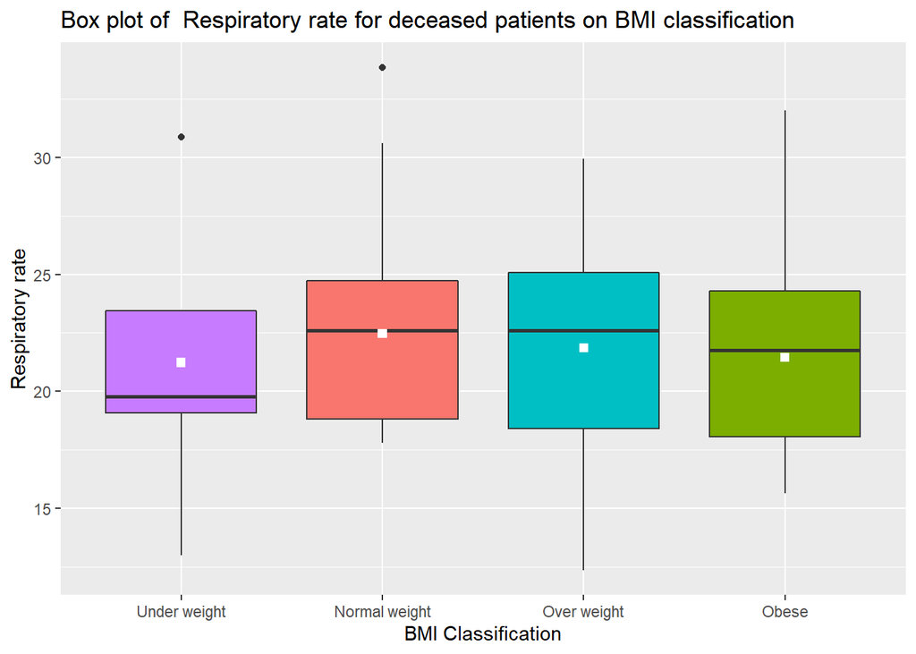

The median respiratory rate for deceased patients for Normal weight and Over weight are almost same and it is higher than that of Under weight category.

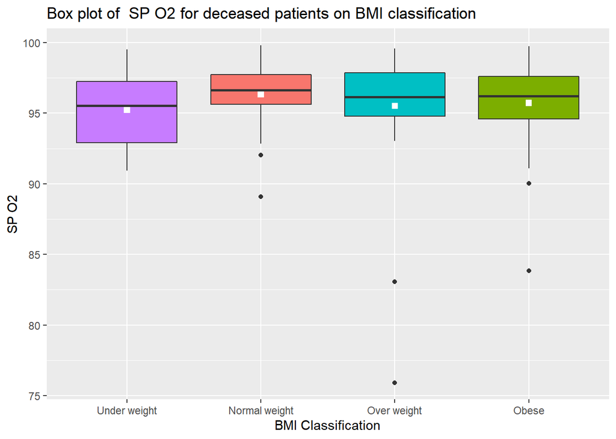

The median of SP O2 for all categories almost same

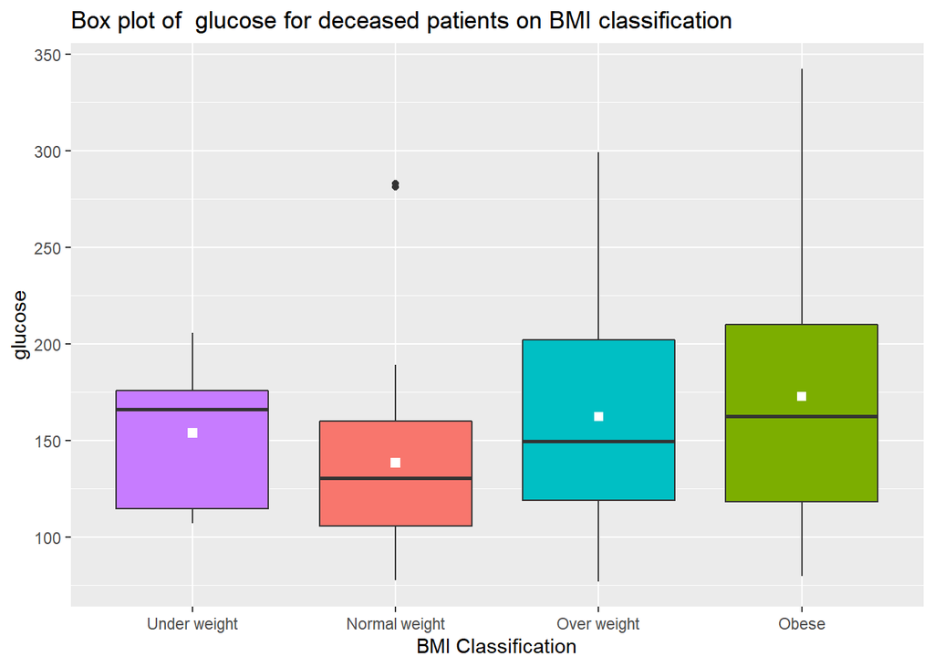

the range of glucose levels for under weight and Normal weight are less compared to that of Over weight and Obese.

### Conclusion

##### Numerical variables

In hospital mortality rate is higher for the following attributes

- age group of 65 to 90
- BMI 21 and 33
- Heart rate 79 to 104
- Systolic Blood Pressure 95 to 125
- Diastolic Blood Pressure 48 to 66
- Respiratory rate between 18 to 21 and 23 to 25.5